# GPS Processing Manual – Wildlife and Applied Genomics Lab

JFW

September 11, 2020

# This is a general manual for dealing with and filtering/cleaning GPS data from wildlife GPS collars

### Title: GPS data filtering/cleaning

### Purpose: Filter and clean GPS data for downstream analysis

### Author: JFW

### Input: .csvs of raw data

### Date: September 11 2020

### Output: single .csv file with all individual data files cleaned and ready for downstream analysis, seasonal data csvs, figure of where movement rates exceed certain value

## General data filtering and cleaning

### Environment setup

```r
libs <- c('data.table', 'ggplot2', 'dplyr', 'readr', 'rgdal')
lapply(libs, require, character.only = TRUE)
```

```
## [[1]]
## [1] TRUE
##
## [[2]]
## [1] TRUE
##
## [[3]]
## [1] TRUE
##
## [[4]]
## [1] TRUE
##
## [[5]]
## [1] TRUE
```

### Read in all .csv files (need to have working directory set to where all the raw files are), combine, and read back in

```r
allgps <- list.files(full.names = TRUE) %>%
  lapply(read_csv) %>%
  bind_rows
# Export to new csv
#write.csv(allgps, combinedgps.csv)
#Read in exported file, encoding it with Latin1 fixes a gsub error I kept getting
allgps <- read_csv("output/combinedGPS.csv", locale = locale(encoding = "Latin1"))
```

### Filter combined csv to only contain relevant information (will be different for everyone) and set proj4string, which tells R where your animals are located according to a UTM zone

```r
#Select only relevant columns of data
gps_simp <-allgps %>%
  select(CollarID, `Mort. Status` ,LMT_Date, LMT_Time, `Height [m]`, DOP,  `Latitude [°]`,`Longitude [°]`,
             FixType, Easting, Northing, AnimalID)
# Setting object to utm zone 9N - THIS DEPENDS ON WHERE THE DATA COMES FROM - CHECK FOR YOUR UTM ZONE
utm9N <-'+proj=utm +zone=9 ellps=WGS84'

# Renaming columns for simplicity
gps_simp <- gps_simp %>%
  rename(Height = `Height [m]`)%>%
  rename (mortality = `Mort. Status`)%>%
  rename (latitude = `Latitude [°]`)%>%
  rename (longitude = `Longitude [°]`)
```

### Filter to remove any lat/longs that are N/A, remove any mortality signals, create a minimum/maximum height value, and ensure filter for whatever date range you’re looking at. This will vary on the individual dataset and objectives as well

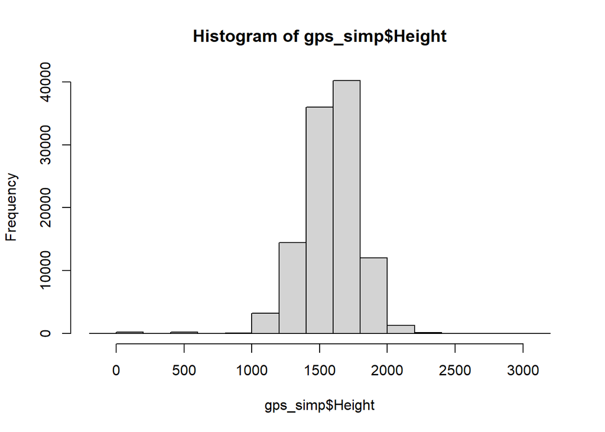

```r
# Histogram of altitude before filtering
hist(gps_simp$Height)
```

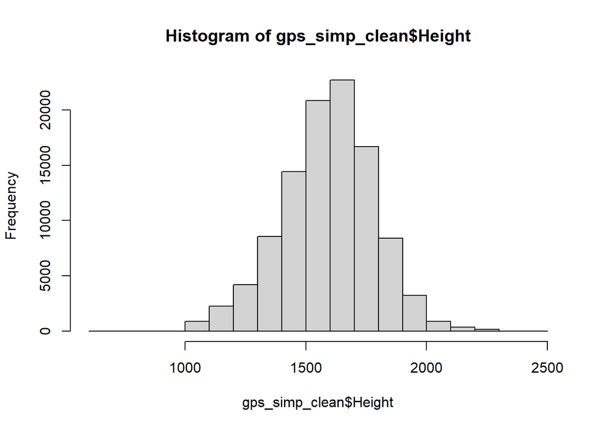

```r
# Filtering data for erroneous points, mortality signals, and height restrictions
gps_simp_clean <- gps_simp %>%
  filter (latitude!="NA") %>%
  filter (longitude!= "NA")%>%
  filter(mortality=="normal")%>%
  filter(Height > 600, `Height` <2500)%>%
  filter(LMT_Date >= as.Date("2018-01-01") & LMT_Date <= as.Date("2020-10-31"))

# Histogram of altitude after filtering
hist(gps_simp_clean$Height)
```

```r
# Export filtered data file
#write.csv(gps_simp_clean, "output/GPS_Simplified_Filtered.csv")
```

### Create a date time variable, and set boundaries

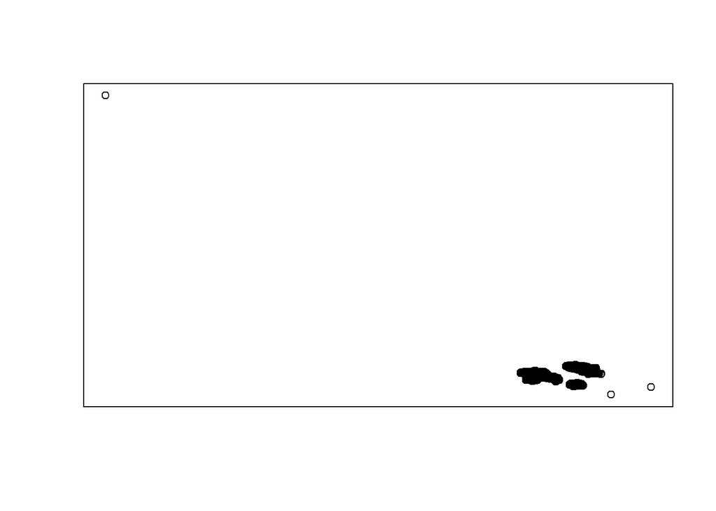

```r
# paste date and time to new variable
datetime <- (paste0 (gps_simp_clean$LMT_Date, sep = " ", gps_simp_clean$LMT_Time))

# bind DateTime to data frame
gps_simp_clean$datetime <- datetime

# making data a data table
gps_simp_clean_dt<-as.data.table(gps_simp_clean)

# Set variable LMTdatetime as proper format to use further
gps_simp_clean_dt [,LMTdatetime := as.POSIXct(datetime)]

# changing coordinates and setting boundaries
# This will create an Easting and Northing column depending on your Longitude/Latitude
gps_simp_clean_dt[, c('EASTING', 'NORTHING') := as.data.table(project(cbind(longitude, latitude), utm9N))]

# What do our easting/northing points look like?
plot(gps_simp_clean_dt$EASTING, gps_simp_clean_dt$NORTHING,
     xaxt='n', yaxt='n', ann=FALSE)
```

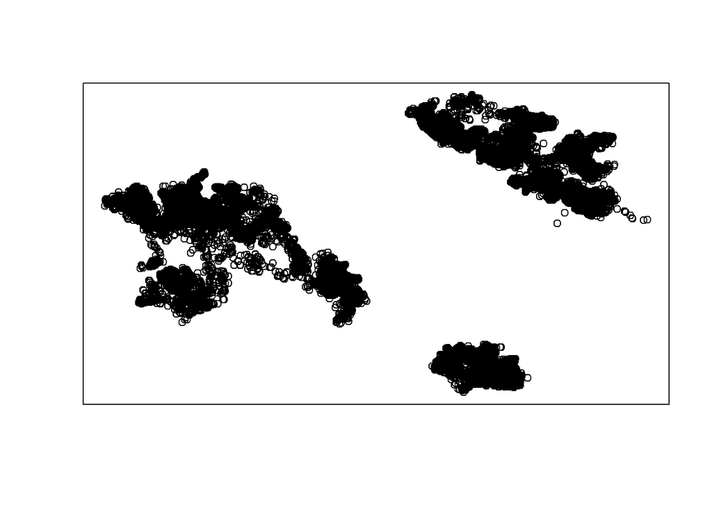

```r
# Generate some sort of boundaries if you see obviously erroneous points in plot above
lowEast <- 600000; highEast <- 640000
lowNorth <- 6000000; highNorth <- 6300000

# Filter by bounds - This will again depend on your study extent but will help
# get rid of those random points off in space
gps_simp_clean_dt <- gps_simp_clean_dt[(lowEast < EASTING & EASTING < highEast) &
                                     (lowNorth < NORTHING & EASTING < highNorth)]
# check to see what it looks like (I removed axes as location data is sensitive)
plot(gps_simp_clean_dt$EASTING, gps_simp_clean_dt$NORTHING,
     xaxt='n', yaxt='n', ann=FALSE)
```

### Calculate number of GPS fixes per individual

```r
#Produces tibble with animal ID and number of fixes
#Animalid is unique ID identifying individual MG
fixes_per_ind <- group_by(gps_simp_clean_dt) %>%
  group_by(AnimalID) %>%
  summarise(number_of_fixes = n())
#write.csv(fixes_per_ind, "output/NumberofFixesPerInd.csv")
```